# fruit_app

## Convolutional Neural Networks

## Project: Write an Algorithm for a fruits Identification App

### Why We're Here

In this notebook, i will make the first steps towards developing an algorithm that could be used as part of a mobile or web app. At the end of this project, my code will accept any user-supplied image as input.and it will provide an estimate of the fruit's category.

### The Road Ahead

i break the notebook into separate steps. Feel free to use the links below to navigate the notebook.

- Step 0: Import Datasets
- Step 1: preprocessing steps supply images to a pre-trained network in Keras
- Step 2: Extract Bottleneck Features for Train set, valid set, Test Set.
- Step 3: rescale the images by dividing every pixel in every image by 255.
- Step 4: Obtain Bottleneck Features
- Step 5: create Model Architecture
- Step 6: Train the Model
- Step 7: Test the Model
- Step 8: Test the Model on Sample Images!

## Step 0: Import fruits Datasets

In the code cell below, i import a dataset of fruit images. We populate a few variables through the use of the `load_files` function from the scikit-learn library:

- `train_files`, `valid_files`, `test_files` - numpy arrays containing file paths to images
- `train_targets`, `valid_targets`, `test_targets` - numpy arrays containing onehot-encoded classification labels
- `fruit_names` - list of string-valued fruit category names for translating labels

```python
from sklearn.datasets import load_files
from keras.utils import np_utils
import numpy as np
from glob import glob

# define function to load train, test, and validation datasets
def load_dataset(path):
    data = load_files(path)
    fruit_files = np.array(data['filenames'])
    fruit_targets = np_utils.to_categorical(np.array(data['target']), 81)
    return fruit_files, fruit_targets

# load train, test, and validation datasets
train_files, train_targets = load_dataset('data/fruit_images/mytrain')
valid_files, valid_targets = load_dataset('data/fruit_images/myvalid')
test_files, test_targets = load_dataset('data/fruit_images/test')

# load list of dog names
fruit_names = [item[26:-1] for item in sorted(glob("data/fruit_images/mytrain/*/"))]

# print statistics about the dataset
print('There are %d total fruit categories.' % len(fruit_names))
print('There are %s total fruit images.\n' % len(np.hstack([train_files, valid_files, test_files])))
print('There are %d training fruit images.' % len(train_files))
print('There are %d validation fruit images.' % len(valid_files))
print('There are %d test fruit images.'% len(test_files))
```

```
There are 81 total fruit categories.
There are 55199 total fruit images.

There are 31983 training fruit images.
There are 9339 validation fruit images.
There are 13877 test fruit images.
```

### Step 1: preprocessing steps supply images to a pre-trained network in Keras

When using TensorFlow as backend, Keras CNNs require a 4D array (which I'll also refer to as a 4D tensor) as input, with shape

$$ (\text{nb_samples}, \text{rows}, \text{columns}, \text{channels}), $$

where `nb_samples` corresponds to the total number of images (or samples), and `rows`, `columns`, and `channels` correspond to the number of rows, columns, and channels for each image, respectively.

The `path_to_tensor` function below takes a string-valued file path to a color image as input and returns a 4D tensor suitable for supplying to a Keras CNN. The function first loads the image and resizes it to a square image that is $100 \times 100$ pixels. Next, the image is converted to an array, which is then resized to a 4D tensor. In this case, since I am working with color images, each image has three channels. Likewise, since I am processing a single image (or sample), the returned tensor will always have shape

$$ (1, 100, 100, 3). $$

The `paths_to_tensor` function takes a numpy array of string-valued image paths as input and returns a 4D tensor with shape

$$ (\text{nb_samples}, 100, 100, 3). $$

Here, `nb_samples` is the number of samples, or number of images, in the supplied array of image paths. It is best to think of `nb_samples` as the number of 3D tensors (where each 3D tensor corresponds to a different image) in my dataset!

```python
from keras.preprocessing import image
from tqdm import tqdm

def path_to_tensor(img_path):
    # loads RGB image as PIL.Image.Image type
    img = image.load_img(img_path, target_size=(100, 100))
    # convert PIL.Image.Image type to 3D tensor with shape (100, 100, 3)
    x = image.img_to_array(img)
    # convert 3D tensor to 4D tensor with shape (1, 100, 100, 3) and return 4D tensor
    return np.expand_dims(x, axis=0)

def paths_to_tensor(img_paths):
    list_of_tensors = [path_to_tensor(img_path) for img_path in tqdm(img_paths)]
    return np.vstack(list_of_tensors)
```

# Step 2: Extract Bottleneck Features for Train set, valid set, Test Set

# Extract Bottleneck Features for Train Set

```python
import keras
import numpy as np
from keras.applications.xception import Xception, preprocess_input
import scipy
from scipy import misc
import os

model = Xception(weights='imagenet', include_top=False)
print('model loaded')

if os.path.exists('bottleneck_features/xception_features_train.npz'):
    print('bottleneck features detected (train)')
else:
    print('bottleneck features file not detected (train)')
    print('calculating now ...')
    xception_input_train = preprocess_input(paths_to_tensor(train_files))
    print('train data preprocessed')
    # extract, process, and save bottleneck features
    features = model.predict(xception_input_train)
    features = np.squeeze(features)
    np.savez('bottleneck_features/xception_features_train', features=features)
print('bottleneck features saved (train)')
```

```
Downloading data from https://github.com/fchollet/deep-learning-models/releases/download/v0.4/xception_weights_tf_dim_ordering_tf_kernels_notop.h5
```

```
model loaded
bottleneck features file not detected (train)
calculating now ...
```

```
train data preprocessed
bottleneck features saved (train)
```

# Extract Bottleneck Features for valid Set

```python
if os.path.exists('bottleneck_features/xception_features_valid.npz'):
    print('bottleneck features detected (valid)')
else:
    print('bottleneck features file not detected (valid)')
    print('calculating now ...')
    xception_input_valid = preprocess_input(paths_to_tensor(valid_files))
    print('valid data preprocessed')
    # extract, process, and save bottleneck features
    features1 = model.predict(xception_input_valid)
    features1 = np.squeeze(features1)
    np.savez('bottleneck_features/xception_features_valid', features=features1)
    print('bottleneck features saved (valid)')
```

```
bottleneck features detected (valid)
```

# Extract Bottleneck Features for test Set

```python
if os.path.exists('bottleneck_features/xception_features_test.npz'):
    print('bottleneck features detected (test)')
else:
    print('bottleneck features file not detected (test)')
    print('calculating now ...')
    xception_input_test = preprocess_input(paths_to_tensor(test_files))
    print('test data preprocessed')
    # extract, process, and save bottleneck features
    features2 = model.predict(xception_input_test)
    features2 = np.squeeze(features2)
    np.savez('bottleneck_features/xception_features_test', features=features2)
print('bottleneck features saved (test)')
```

```
bottleneck features file not detected (test)
calculating now ...
```

```
test data preprocessed
bottleneck features saved (test)
```

### Step 3: rescale the images by dividing every pixel in every image by 255.

I rescale the images by dividing every pixel in every image by 255.

```python
from PIL import ImageFile
ImageFile.LOAD_TRUNCATED_IMAGES = True

# pre-process the data for Keras
train_tensors = paths_to_tensor(train_files).astype('float32')/255
valid_tensors = paths_to_tensor(valid_files).astype('float32')/255
test_tensors = paths_to_tensor(test_files).astype('float32')/255
```

### Step 4: Obtain Bottleneck Features

```python
train_Xception = np.load('bottleneck_features/xception_features_train.npz')['features']
valid_Xception = np.load('bottleneck_features/xception_features_valid.npz')['features']
test_Xception = np.load('bottleneck_features/xception_features_test.npz')['features']
```

### Step 5: create Model Architecture and compile

```python
from keras.layers import Conv2D, MaxPooling2D, GlobalAveragePooling2D
from keras.layers import Dropout, Flatten, Dense
from keras.models import Sequential


xception_model = Sequential()
xception_model.add(GlobalAveragePooling2D(input_shape=train_Xception.shape[1:]))
xception_model.add(Dense(81, activation='softmax'))

xception_model.summary()
```

```
_________________________________________________________________
Layer (type)                 Output Shape              Param #
=================================================================
global_average_pooling2d_1 ( (None, 2048)              0
_________________________________________________________________
dense_1 (Dense)              (None, 81)                165969
=================================================================
Total params: 165,969
Trainable params: 165,969
Non-trainable params: 0
_________________________________________________________________
```

```python
xception_model.compile(loss='categorical_crossentropy', optimizer='rmsprop', metrics=['accuracy'])
```

### Step 6: Train the Model

```python
from keras.callbacks import ModelCheckpoint

mycheckpointer= ModelCheckpoint(filepath='saved_models/weights.best.myXception.hdf5', verbose=1, save_best_only=True)

xception_model.fit(train_Xception, train_targets, validation_data=(valid_Xception, valid_targets),
          epochs=20, batch_size=20, callbacks=[mycheckpointer], verbose=1)
```

```
Train on 31983 samples, validate on 9339 samples
```

```
<keras.callbacks.History at 0x7f601422ad30>
```

### Load the Model with the Best Validation Loss

```python
xception_model.load_weights('saved_models/weights.best.myXception.hdf5')
```

### Step 7: Test the Model

```python
xception_predictions = [np.argmax(xception_model.predict(np.expand_dims(feature, axis=0))) for feature in test_Xception]

test_accuracy_xception = 100*np.sum(np.array(xception_predictions)==np.argmax(test_targets, axis=1))/len(xception_predictions)
print('Final test accuracy: %.4f%%' % test_accuracy_xception)
```

```
Final test accuracy: 95.5610%
```

### Predict fruit category with the Model

```python
from extract_bottleneck_features import *

def Xception_predict_category(img_path):
    # extract bottleneck features
    bottleneck_feature = extract_Xception(path_to_tensor(img_path));
    # obtain predicted vector
    predicted_vector = xception_model.predict(bottleneck_feature);
    # return dog breed that is predicted by the model
    return fruit_names[np.argmax(predicted_vector)]
```

### show image and estimate of the fruit's category.

```python
import cv2
import matplotlib.pyplot as plt
%matplotlib inline

def fruit_category_classifier(img_path):
    # Load BGR image
    img_bgr = cv2.imread(img_path)

    # Convert BGR to RGB image for plotting
    img_rgb = cv2.cvtColor(img_bgr, cv2.COLOR_BGR2RGB)

    # Show image and remove axis
    plt.axis("off")
    plt.imshow(img_rgb)
    plt.show()

    # Predict using ResNet50
    predicted_category = Xception_predict_category(img_path)

    print("it look like a %s" % predicted_category )
```

### Step 8: Test the Model on Sample Images!

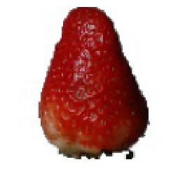

```
it look like a Strawberry Wedge
```

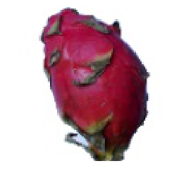

```
it look like a Pitahaya Red
```

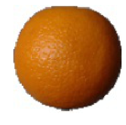

```
it look like a Orange
```

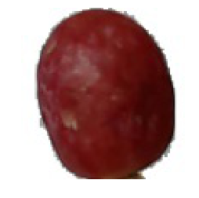

```
it look like a Grape Pink
```

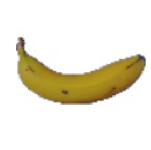

```
it look like a Banana Red
```

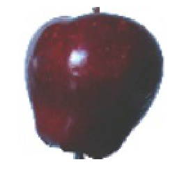

```
it look like a Apple Red Delicious
```

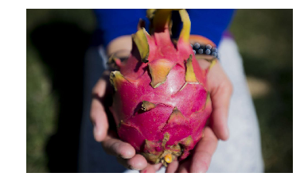

```
it look like a Mulberry
```

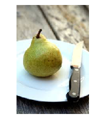

```
it look like a Physalis
```

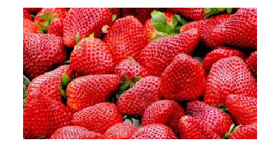

```
it look like a Mandarine
```

```python
fruit_category_classifier('test_images/1.jpg')
fruit_category_classifier('test_images/2.jpg')
fruit_category_classifier('test_images/3.jpg')
fruit_category_classifier('test_images/4.jpg')
fruit_category_classifier('test_images/5.jpg')
fruit_category_classifier('test_images/6.jpg')
fruit_category_classifier('test_images/7.jpg')
fruit_category_classifier('test_images/8.jpg')
fruit_category_classifier('test_images/9.jpg')
```